# Proiect Probabilități și Statistică - infracțiunile din Statele Unite ale Americii comise în anul 1973

Toader Vlad-Marian, Florea Maria-Alexandra, Cordun Diana-Alexandra

28-01-2022

## Descrierea proiectului

Aplicația noastră utilizează date din DataFrame-ul USArrests, creat pe baza unui studiu efectuat pe un eșantion de 100,000 persoane în anul 1973: crime, asalturi și agresiuni sexuale.

Pentru realizarea proiectului, am utilizat librăriile shiny și data.table.

## Secțiunea principală a aplicației

În secțiunea principală a aplicației, avem două grafice și un tabel.

## Grafic de tip barplot

Codul de mai jos creează graficul cu informații generale despre infracțiunile comise în toate statele în anul 1973.

```r
output$generalPlot <- renderPlot({

    state.names <- row.names(USArrests)
    barplot(USArrests$Assault,names.arg = state.names, las = 2, ylab = "Rata de arest per 100,000", main = "Rata de arest din SUA în 1973", ylim = c(0,350), col = "green")
    barplot(USArrests$Rape, las = 2, col = "blue", add = TRUE)
    barplot(USArrests$Murder, las=2, col = "red", add = TRUE)

    legend(x = "topright", legend = c('Asalt','Agresiune sexuală','Crimă'),col=c("green","blue","red"),pch=15)

    })
```

Rezultatul codului scris anterior este graficul următor:

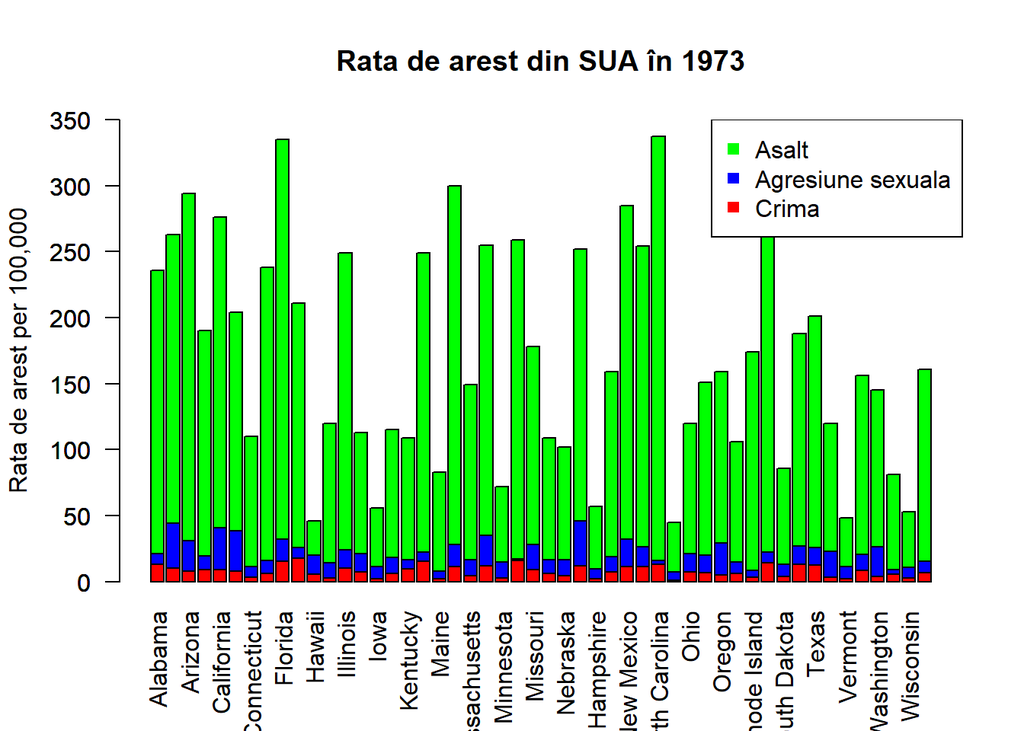

## Diagrama de împrăștiere

Următorul cod creează o diagramă de împrăștiere care reprezintă într-un sistem de axe, având coordonate rata de asalt și rata de crimă, fiecare stat.

```r
 output$scatterPlot <- renderPlot({
    plot(y = USArrests$Murder, x = USArrests$Assault, xlab = "Rata de asalt", ylab = "Rata de crimă", main = "Rata de crimă vs. rata de atac, SUA, 1973")
  })
```

Diagrama arată astfel:

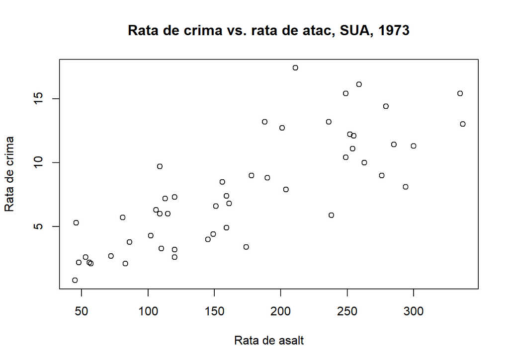

## Tabel cu date

Următoarea bucată de cod preia datele din DataFrame-ul USArrests și le afișează sub formă de tabel.

```r
 output$table <- renderDataTable({

    keep <- c("Murder", "Assault", "Rape")

    df <- USArrests[keep]

    colnames(df) <- c('Rata de crimă','Rata de asalt','Rata de agresiune sexuală')

    as.data.table(df, keep.rownames="Stat")})
```

Datele sunt afișate astfel:

|  | Rata de crima | Rata de asalt | Rata de agresiune sexuala |
| --- | --- | --- | --- |
| Alabama | 13.2 | 236 | 21.2 |
| Alaska | 10.0 | 263 | 44.5 |
| Arizona | 8.1 | 294 | 31.0 |
| Arkansas | 8.8 | 190 | 19.5 |
| California | 9.0 | 276 | 40.6 |
| Colorado | 7.9 | 204 | 38.7 |
| Connecticut | 3.3 | 110 | 11.1 |
| Delaware | 5.9 | 238 | 15.8 |
| Florida | 15.4 | 335 | 31.9 |
| Georgia | 17.4 | 211 | 25.8 |
| Hawaii | 5.3 | 46 | 20.2 |
| Idaho | 2.6 | 120 | 14.2 |
| Illinois | 10.4 | 249 | 24.0 |
| Indiana | 7.2 | 113 | 21.0 |
| Iowa | 2.2 | 56 | 11.3 |
| Kansas | 6.0 | 115 | 18.0 |
| Kentucky | 9.7 | 109 | 16.3 |
| Louisiana | 15.4 | 249 | 22.2 |
| Maine | 2.1 | 83 | 7.8 |
| Maryland | 11.3 | 300 | 27.8 |
| Massachusetts | 4.4 | 149 | 16.3 |
| Michigan | 12.1 | 255 | 35.1 |
| Minnesota | 2.7 | 72 | 14.9 |
| Mississippi | 16.1 | 259 | 17.1 |
| Missouri | 9.0 | 178 | 28.2 |
| Montana | 6.0 | 109 | 16.4 |
| Nebraska | 4.3 | 102 | 16.5 |
| Nevada | 12.2 | 252 | 46.0 |
| New Hampshire | 2.1 | 57 | 9.5 |
| New Jersey | 7.4 | 159 | 18.8 |
| New Mexico | 11.4 | 285 | 32.1 |
| New York | 11.1 | 254 | 26.1 |
| North Carolina | 13.0 | 337 | 16.1 |
| North Dakota | 0.8 | 45 | 7.3 |
| Ohio | 7.3 | 120 | 21.4 |
| Oklahoma | 6.6 | 151 | 20.0 |
| Oregon | 4.9 | 159 | 29.3 |
| Pennsylvania | 6.3 | 106 | 14.9 |
| Rhode Island | 3.4 | 174 | 8.3 |
| South Carolina | 14.4 | 279 | 22.5 |
| South Dakota | 3.8 | 86 | 12.8 |
| Tennessee | 13.2 | 188 | 26.9 |
| Texas | 12.7 | 201 | 25.5 |
| Utah | 3.2 | 120 | 22.9 |
| Vermont | 2.2 | 48 | 11.2 |
| Virginia | 8.5 | 156 | 20.7 |
| Washington | 4.0 | 145 | 26.2 |
| West Virginia | 5.7 | 81 | 9.3 |
| Wisconsin | 2.6 | 53 | 10.8 |
| Wyoming | 6.8 | 161 | 15.6 |

## Secțiunea particulară per stat

Folosind următorul cod, am creat o secțiune prin care, utilizând o listă drop-down, se pot vizualiza informații despre infracțiunile din fiecare stat, în funcție de alegerea făcută.

În partea de user interface:

```r
    sidebarPanel(

      selectInput("var",
                  label = "Alegeți un stat pentru a vedea statistici detaliate",
                  choices = row.names(USArrests),
                  selected = "Alabama"),
      textOutput("selected_var"),
      br(),
      plotOutput(outputId = "statePlot"),

    )
```

În partea de server:

```r
output$statePlot <- renderPlot({

    keep <- c("Assault", "Rape", "Murder")

    barplot(t(USArrests[input$var,][keep]), beside=TRUE,  ylab = "Rata de arest per 100,000", main = paste("Rata de arest din ", input$var, ", 1973", sep=""), ylim = c(0,350), col=c("green", "blue", "red"))

      legend(x = "topright", legend = c('Asalt','Agresiune sexuală','Crimă'),col=c("green","blue","red"),pch=15, cex = .75)

output$selected_var <- renderText({
    paste('Statul selectat: ', input$var, sep="")
  })
  })
```

Rezultatul codurilor de mai sus este următoarea secțiune (dacă este selectat statul California):

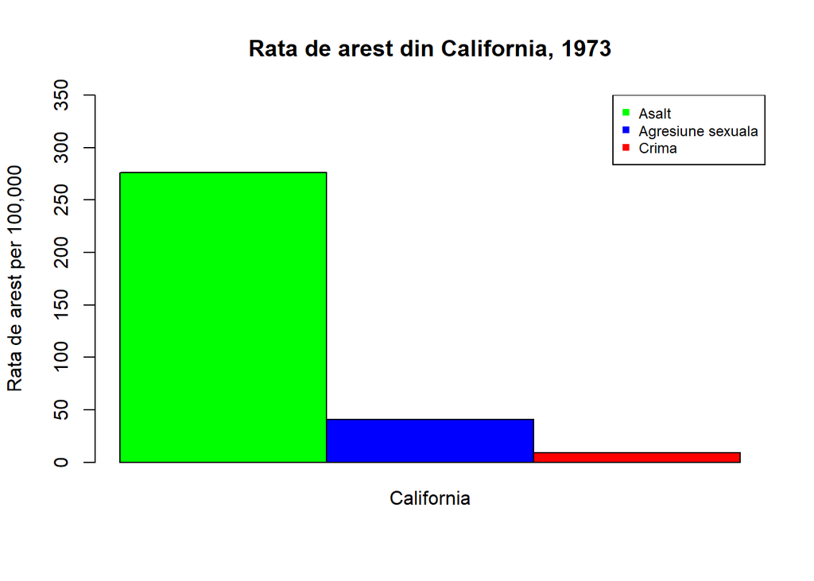